Vamsi Gudipati

Portfolio · Physics-informed learning · October 2026

# Physics in the loss: PINNs for forward and inverse heat problems, and a DeepONet for a whole family

One training loop asked three questions. Solve this field: a physics-informed network written by hand reproduces transient heat conduction to a few thousandths. Find this coefficient: one trainable number and twelve sensor readings recover a conductivity, when the readings allow it and the optimiser runs its course. Learn the whole family: a DeepONet trained on 1,500 solver runs maps any permeability field to its pressure in one pass.

**Vamsi Gudipati** Physics-informed neural networks · Inverse problems · Neural operators [Repository](https://github.com/vamsigudipati/physics-informed-pinn-deeponet)

0.0041 ± 0.0016

maximum error of the hand-written rod PINN against the exact field (3 seeds)

0.839 ± 0.026

conductivity recovered from 12 sensors, true 0.8 (3 seeds)

3.888 ± 0.029

λ recovered by hand from 4 observations, true 4 (3 seeds)

0.0704 ± 0.0053

DeepONet validation error on 80 unseen fields (3 seeds)

0.30 → 0.064

DeepONet test error, 150 against 1,500 training fields

## Objective

A partial differential equation (PDE) relates a field, a temperature or a pressure, to its derivatives. The usual way to solve one is a grid solver. I wanted to find out, on problems whose answers I know, what a neural network that is given the equation can actually do instead, and for which question it earns its place. The work is five stages, each a notebook, built on one training loop:

1. **Stage 1 — A PINN for heat conduction, written by hand.** A physics-informed neural network (PINN) written in plain PyTorch: transient heat conduction in a rod, then a cylindrical fuel pin and a two-dimensional plate, with six short studies and five experiments on what makes it work or fail.
2. **Stage 2 — The same recipe in DeepXDE, then turned into an inverse problem.** The same recipe as library calls, a forward solve on a square, then the conductivity recovered from twelve sensor readings, plus a viscosity, two cases where the data cannot identify the unknown, and a moving solidification front.
3. **Stage 3 — The inverse problem by hand.** The inverse idea in a few lines of PyTorch: λ in y'' + λy = 0 from four observations.
4. **Stage 4 — A DeepONet that learns a whole family of Darcy problems.** A deep operator network (DeepONet) trained on 1,500 solver runs that maps any permeability field of a family to its pressure field in one pass.
5. **Stage 5 — Data efficiency and noise robustness across the stages.** Two questions across the stages: how much data the operator needs, and how the library and the hand-written inverse PINN react to noisy readings.

Every trained result is repeated with three seeds, so that a difference is called an effect only when it is larger than the spread between repeats.

## Problem statement

One loop runs through all five stages: a network, a loss, an optimiser. What changes is what the loss is built from and what comes out of it. With the equation and its boundary and initial conditions, the answer is one field. Add one trainable number and a few readings, and the answer is a field plus a coefficient, provided the readings determine it. Replace the equation by solved input–output pairs, and the answer is a network that serves a whole family of inputs.

[figure not shown]

**What stays fixed is the loop; what is exchanged is what the loss is built from and what comes out.** Blue: physical inputs and results; green: data; violet: the training loops. The dashed arrows are the two changes: *add* an unknown and a data term, *replace* the residual by solved pairs.

No file passes between the stages: each builds its own points, readings or training pairs from code, and each one knows the true answer because it made its data from it. That makes every result checkable, and it is also the main limit: all readings are synthetic and consistent with the equation.

[figure not shown]

**How the stages connect.** Every arrow is dashed because no file passes; the label says whether a method or a code pattern does. The accent boxes are Stage 5, placed under the stages whose code it copies.

The questions: does a hand-written PINN reproduce a known field, and what settings decide whether it does? Can the same loop recover a material coefficient from a handful of sensors, and when can it not? What does a library add over a dozen lines of PyTorch? And when is it worth learning the whole map from input field to solution instead of solving one case at a time?

## Method

### The residual, from automatic differentiation

A small tanh network maps coordinates to a field. Automatic differentiation takes its derivatives with respect to those coordinates exactly; keeping the computation graph lets the loss be differentiated again with respect to the weights, through the derivatives. The equation, rearranged to read "this should be zero", is evaluated at a few thousand random points, squared and averaged. Initial and boundary values are further mean-square terms, each with a weight. Training is Adam first, then a short L-BFGS stage (a quasi-Newton optimiser that uses curvature estimated from recent gradients).

[figure not shown]

**Stage 1's residual for the rod, ∂T/∂t = 0.4 ∂²T/∂x² + q.** A 2–32–32–32–1 tanh network gives T(x, t); two calls of the gradient give T_t and T_xx; the residual is averaged over 2,000 collocation points.

The rod's reference is a manufactured solution, T(x, t) = e^(−t) sin(πx) + x(1 − x): I pick the answer first and derive the source term from it, so any error is the network's own. An implicit finite-difference solver agrees with that field to 0.00025, which confirms the setup before any network is trained.

### The inverse move: one trainable number

An inverse PINN differs from a forward one by a single registration: the unknown coefficient becomes a parameter the optimiser updates next to the weights, and a mean-square term over the sensor readings replaces the information the coefficient used to provide. Stage 2 does it in DeepXDE, Stage 3 by hand; the two columns below correspond one to one.

[figure not shown]

**The same inverse idea in the library and by hand.** Blue: the unknown; violet: the network and its derivatives; orange: loss terms and optimiser. What differs is what surrounds the two lines: DeepXDE adds an L-BFGS stage, the hand-written loop trains with Adam alone.

### An operator instead of one solution

A PINN learns one solution; change a coefficient and it must be trained again. Stage 4 learns the operator that takes a whole permeability field to the pressure field of steady Darcy flow, −∇·(a∇u) = 1 on the unit square. A branch network reads the permeability at the 100 grid points, a trunk network reads a query location, and their dot product is the pressure there. The training pairs come from a finite-volume solver: two-material blocky fields with permeabilities 3 and 12, 1,500 for training and 80 held out.

[figure not shown]

**Branch and trunk, joined only at the last step.** The branch turns 100 permeability values into 128 coefficients, the trunk turns a coordinate pair into 128 basis values, and B·Tᵀ + b₀ gives the pressure at every grid point; 112,385 weights in all.

### Baselines and references

- Exact or manufactured solutions where one exists (the rod, the plate, λ = 4 with sin(2x)), a finite-difference solver otherwise (the fuel pin, the square with k = 0.8).
- For the operator, the finite-volume solver on 80 held-out fields, and four hand-drawn fields outside the training family.
- For every trained result, three seeds (0, 1, 2), so each comparison is against the spread between repeats.

## Implementation

What was run, and with what.

[output not shown]

## Results 1 — A field solved by hand (Stage 1)

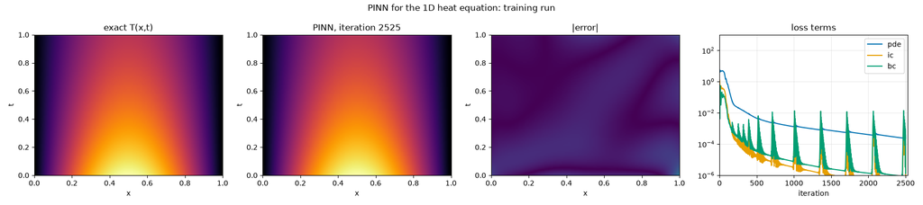

**The rod after training.** Exact field, prediction, absolute error and the three loss terms over 2,525 iterations (2,500 Adam, then 25 L-BFGS).

Each problem trains in 10 to 13 s on the CPU; the one-run column is the first training of each problem.

| Problem | Error (3 seeds) | One run |
| --- | --- | --- |
| Rod, max error vs exact | 0.0041 ± 0.0016 | 0.0028 |
| Rod, RMSE vs exact | 0.00078 ± 0.00033 | 0.0005 |
| Rod + 12 noisy sensors, RMSE | 0.0027 ± 0.0003 | — |
| Fuel pin, RMSE vs FD (rise 17.19 K) | 0.253 ± 0.068 K | 0.328 K |
| Plate at t = 0.3, RMSE | 0.0040 ± 0.0014 | 0.0044 |
| Rod in DeepXDE, max error | 0.0178 ± 0.0117 | — |

The hand-written PINN reproduces the manufactured rod field to a maximum error of a few thousandths, and the same `MLP`, gradient helper and training loop carry over unchanged to the fuel pin and the plate. The DeepXDE version of the rod is less accurate and less repeatable here (0.0078 to 0.0308 over three seeds) with Adam alone for 3,000 iterations.

### What decides whether it works

[figure not shown]

**Six short studies, one run each.** Maximum error against the exact field, logarithmic scale. At its default settings the same small trainer varies from 0.014 to 0.067 over three seeds, so the first five groups differ by about the size of that spread; the activation is the only setting whose effect is a failure.

[figure not shown]

**Five experiments with three seeds each.** Bars: mean RMSE, whisker one standard deviation, dots the single runs. Only two effects exceed the spread: extreme loss weights and the long fuel-pin window.

- **Loss weights matter at the extremes.** With weights 0.01 on the initial and boundary terms the RMSE is 0.234 ± 0.072 against 0.021 ± 0.026 at the default: the network satisfies the equation and ignores the data, which is another solution of the same equation. One tiny and one huge weight (0.01, 1000) give 0.557 ± 0.131.
- **A longer fuel-pin window is harder, not easier.** Ten seconds instead of two raise the RMSE to 8.41 ± 2.68 K with the same budget; the residual loss stays two orders of magnitude higher.
- **Not resolved:** the strength of the steady part of the field, more interior points on the plate (0.0138 ± 0.0169 with 6,000 against 0.0040 ± 0.0014 with 2,500, two of the draws much worse), and the L-BFGS polish on the fuel pin (0.306 ± 0.203 K without it against 0.253 ± 0.068 K).

## Results 2 — Turning it around: a conductivity from twelve sensors (Stage 2)

The forward PINN on the square matches the 61 × 61 finite-difference field to a maximum error of 0.0109 (one run; 0.027 ± 0.028 over three seeds, one of which stopped its L-BFGS stage after 3 steps). For the inverse problem, the conductivity k becomes a trainable variable starting at 1.5, and twelve readings of the reference field join the loss.

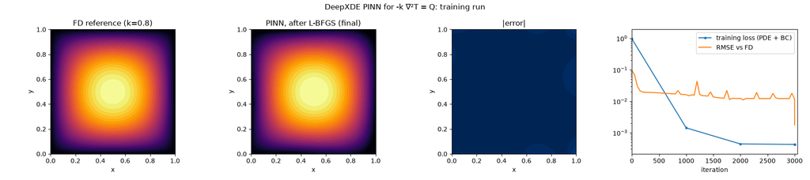

**The forward solve on the square.** Reference, PINN after L-BFGS, absolute error and the training curves; the error against the reference drops sharply in the L-BFGS stage at the end.

[figure not shown]

**Only the full recipe moves k.** Recovered conductivity, one dot per seed. With Adam then L-BFGS, k reaches 0.839 ± 0.026 (true 0.8). Every placement and noise study that uses Adam alone ends between 1.51 and 1.61, near the starting value 1.5; the full recipe's own Adam stage ends there too.

Error on k 4.9 ± 3.2 %; on the viscosity 0.33 %.

| Case | Recovered | True |
| --- | --- | --- |
| k, 12 sensors, Adam + L-BFGS (3 seeds) | 0.839 ± 0.026 | 0.8 |
| k after the Adam stage alone | 1.507 – 1.532 | 0.8 |
| Viscosity from 10 velocities (3 seeds) | 0.02007 ± 0.00000 | 0.02 |
| Viscosity, pressure gradient doubled | 0.0402 | 0.02 |
| k with no source term (3 seeds) | 1.431 ± 0.006 | not identifiable |
| Front coefficient β, Stefan problem | 0.92957 ± 0.00000 | 0.9296 |

**The L-BFGS stage does the recovery.** After 3,000 Adam iterations k was still 1.51 to 1.53 in every run; L-BFGS, running its 1,000 iterations, brought it to 0.81 to 0.87. An earlier execution on the Apple GPU gave k = 1.0585 with the same code and seed, because its L-BFGS stage stopped after 59 iterations. I now read the L-BFGS iteration count before I read the recovered value.

**A low loss does not mean the unknown was found.** The Poiseuille profile depends on viscosity and pressure gradient only through their ratio, so a doubled gradient gives a doubled viscosity (ratio 49.74 against 49.82). With no source term the residual multiplies k by a Laplacian the solution makes zero; the readings are fitted and k stays near its start.

The solidification front is the clean case: the coordinate ξ = x/s(t) freezes the moving boundary, and the front coefficient comes out at the exact value in all three seeds without any sensor readings, because the Stefan condition alone pins it.

## Results 3 — The same inverse problem by hand (Stage 3)

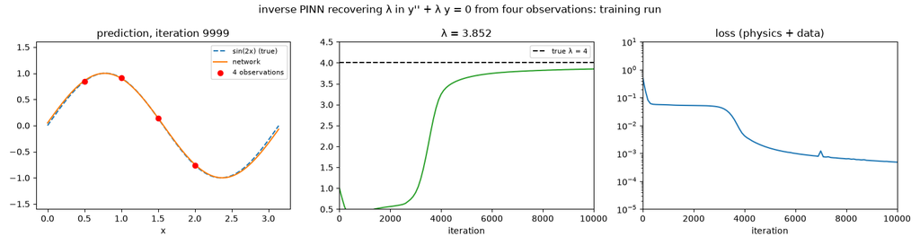

**Fifty trainable numbers.** Left: the network against sin(2x) with the four observations; middle: λ over 10,000 Adam iterations, in this unseeded run ending at 3.852; right: the total loss.

[figure not shown]

**λ after 10,000 iterations.** Two unseeded runs and the three seeds; true value 4.

With seeds 0, 1 and 2, λ ends at 3.909, 3.855 and 3.901: **3.888 ± 0.029**, an error of 2.8 ± 0.7 %. Each run takes 2.8 s. Every run ends below 4 and the trajectory is still rising after 10,000 iterations; continuing for another 10,000 brings the unseeded run in the figure from 3.852 to 3.915. Another unseeded run, in the repository's notebook, reached 3.984 and 3.990: without a seed, a single number here is one draw.

Side by side with Stage 2, the inverse idea itself is two lines in either form. What decides the result is everything around them: the L-BFGS stage that DeepXDE has and this loop lacks, whether the readings determine the unknown, the seed and even the device.

## Results 4 — A whole family: DeepONet for Darcy flow (Stage 4)

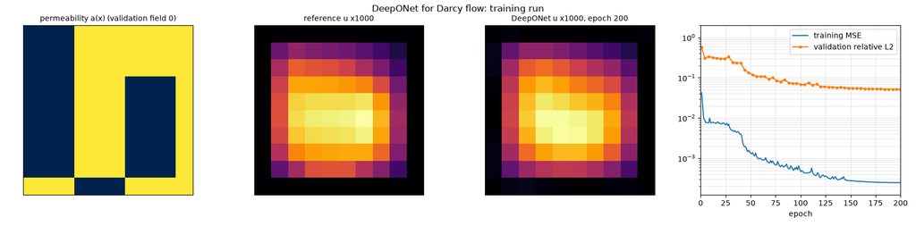

**One unseen validation field.** Permeability, the solver's pressure, the DeepONet prediction after 200 epochs, and the training MSE with the validation error, which falls from 0.573 after the first epoch to 0.052.

The first model reached a validation relative L2 error of 0.052. Three further initialisations on the same data give **0.0704 ± 0.0053**, so 0.052 is a good draw, not the typical result. On a 16 × 16 grid a fresh model reaches 0.0840 ± 0.0030. The branch reads a fixed number of values, so a field on another grid cannot be fed to a trained model: changing the grid means a new branch and new data.

[figure not shown]

**What moves the error.** Validation error over three seeds (dots, mean ± std) and one run (diamonds). More fields and more epochs lower it beyond the spread; sharper material contrasts raise it; the number of basis functions and the grid size do not matter once p is 16 or more.

[figure not shown]

**Outside the family.** Four hand-drawn permeabilities through the three seed models; the farther from the blocky two-material family, the worse the answer.

A learned operator gives no warning when asked about something it was not trained on; it still returns a field. A checkerboard finer than any training block gives 0.233 ± 0.080 and is predicted too low everywhere; a uniform field, which is just a block filling the square, gives 0.024 ± 0.002.

Single timings; on this small grid the speed-up is not the point.

| Cost | Value |
| --- | --- |
| Solver, one field (10 × 10) | 0.18 ms |
| DeepONet, one field (batched) | 0.010 ms |
| Offline: 1,580 solves + training | about 11.3 s |
| Break-even | about 66,000 queries |

## Results 5 — Data and noise across the stages (Stage 5)

### How much data the operator needs

[figure not shown]

**Test error against the number of training fields.** Orange: mean ± std over three seeds; grey: single runs; violet: three repeats of the full set from Stage 4. Both axes logarithmic.

Same 80 test fields throughout; a different random subset for each seed. The seed-0 training at 10 % moves in the fourth digit between fresh kernels (0.2998 to 0.3042), cause not found; the figure shows an earlier execution.

| Training fields | Test relative L2 (3 seeds) |
| --- | --- |
| 150 (10 %) | 0.3044 ± 0.0002 |
| 375 (25 %) | 0.2270 ± 0.0124 |
| 750 (50 %) | 0.0882 ± 0.0076 |
| 1,500 (100 %) | 0.0639 ± 0.0068 |

Every step is larger than the spread on either side, with the steepest drop between 375 and 750 fields. One caveat: at a fixed 200 epochs, fewer fields also mean fewer optimiser steps (1,000 against 9,400), so this measures data and training length together. A PINN's collocation points cost nothing to make; each operator pair costs a solver run.

### How the two inverse PINNs react to noise

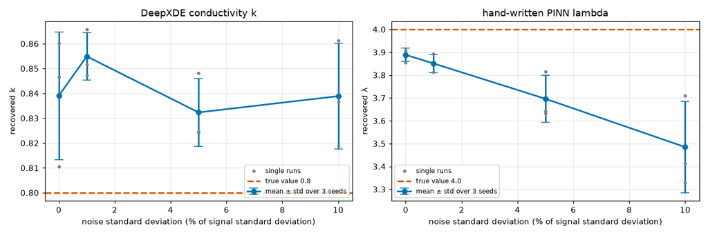

**Noise of 0, 1, 5 and 10 % of the readings' standard deviation,** three seeds each, both with their full recipe; dashed: the true value.

Error on k 4.0 to 6.9 % at every level; on λ from 2.8 % to 12.9 ± 5.0 %.

| Noise | DeepXDE k (true 0.8) | By hand λ (true 4) |
| --- | --- | --- |
| 0 % | 0.839 ± 0.026 | 3.888 ± 0.029 |
| 1 % | 0.855 ± 0.010 | 3.851 ± 0.040 |
| 5 % | 0.832 ± 0.014 | 3.696 ± 0.103 |
| 10 % | 0.839 ± 0.021 | 3.485 ± 0.200 |

By hand, the error grows steadily with the noise and every run ends below 4; from 5 % on the effect is larger than the spread. In DeepXDE, k stays a few per cent above 0.8 at every level, and the means do not order with the noise, so up to 10 % three seeds cannot resolve an effect. This is not a contest between the two: the noise on the twelve temperatures is small in absolute terms (at most 0.0018 against 0.078 for the four values of sin(2x)), and the hand-written loop has no L-BFGS stage.

## Key observations

1. **One recipe, three roles.** The same loop of network, residual and optimiser solves a field to a few thousandths, recovers a coefficient to within a few per cent, and, with the residual replaced by solver pairs, answers a whole family of inputs to about 6 to 8 % error.
2. **The activation is a correctness choice, not a tuning choice.** With ReLU the second derivative vanishes and the PINN fails (3.175 against 0.018); every network whose loss contains a derivative needs a smooth activation.
3. **In an inverse problem, the optimiser's second stage does the work.** Adam alone left the conductivity at its starting value in every run; L-BFGS recovered it. A stage that stops after seconds leaves a leftover of the starting guess, and the same code gave 1.0585 on the GPU and 0.8466 on the CPU for that reason.
4. **A fitted loss is not an identified unknown.** A ratio of two parameters and a field whose Laplacian is zero both fit the readings well and recover the wrong value; the readings decide identifiability, not the optimiser.
5. **Single runs mislead in both directions.** The DeepONet's 0.052 is a good draw (0.0704 ± 0.0053); several effects in the PINN studies vanish inside the seed spread; two others, extreme loss weights and the long window, survive it.
6. **An operator pays for itself only inside its family and at volume.** Error falls steadily with training data, rises sharply on fields unlike the training set, and on a small grid the break-even is tens of thousands of queries.

## Conclusion

On problems with known answers, a network that is given the equation works: as a forward solver, as an inverse solver for a scalar coefficient, and as an operator over a family of inputs. The numbers that survive three seeds are the ones I would build on; the ones that do not are single runs, and a few of the most visible numbers in these notebooks were exactly that.

For a single forward problem the classical solver remains the default: it was the reference in every stage. A PINN earns its place when sparse, noisy readings have to be combined with an equation, and an operator when the same kind of problem is asked many times. What these stages do not establish is a comparison with the simplest classical alternative for the same task (a least-squares fit for λ, the finite-difference solver inside an optimiser for k, a linear map for the operator), a recovered value checked against held-out readings, or the operator's speed-up on a grid where the solver is slow. Those are the next steps, together with an L-BFGS stage for the hand-written loop and a nudge test of each recovered value.

## Code, data and reproducibility

The five notebooks of the repository, each also exported as HTML with all outputs.

| Notebook | Stage |
| --- | --- |
| `01_pinn_heat_conduction_from_scratch.ipynb` | Stage 1 — A PINN for heat conduction, written by hand |
| `02_deepxde_forward_and_inverse.ipynb` | Stage 2 — The same recipe in DeepXDE, then turned into an inverse problem |
| `03_inverse_pinn_by_hand.ipynb` | Stage 3 — The inverse problem by hand |
| `04_deeponet_darcy_operator.ipynb` | Stage 4 — A DeepONet that learns a whole family of Darcy problems |
| `05_data_efficiency_and_noise.ipynb` | Stage 5 — Data efficiency and noise robustness across the stages |

| Item | Where |
| --- | --- |
| Repository | vamsigudipati/physics-informed-pinn-deeponet: the five executed notebooks, result tables and figures, trained models for every seed, training checkpoints and animations |
| Data | None external: every reference is a manufactured or exact solution, or a finite-difference or finite-volume solver written in the notebook |
| Environment | `requirements.txt` in the repository (Python 3.12, PyTorch 2.14.1, DeepXDE 1.15.0 with the PyTorch back end) |
| Run | Everything runs on a laptop CPU; the whole set takes under an hour, and each training 3 to 13 s |